# Heart Disease Prediction and Indicators

by Priyanka Nagesh Adiga and Anubhav Saha

[figure not shown]

### **Introduction**

Heart Disease or Cardiovascular disease is a class of disease that involves the heart and the blood vessels. Cardio vascular diseases are the leading causes of death all over the world. In this project, we have conducted the analysis of the heart disease data set in order to identify the factors that indicate the onset of a heart disease and also build a model that predicts the presence of a heart disease given certain parametets with certain accuracy.

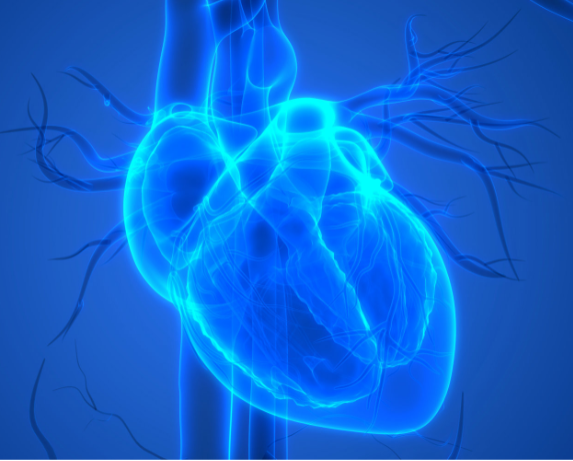

We start by understanding the data through descriptive statistics and graphical visualizations and then perform hypothesis testing to test a popular belief that heart disease is predominantly the disease of the elderly. We then perform logistic regression to eliminate the parameters that don’t contribute in the prediction of a heart disease and finally use the classification method of decision tree to obtain a decision tree for the presence of a heart disease.

### **Goals and methods**

With this project we are using our acquired skills of Intermediate Analytics in order to uncover useful aspects of the data under analysis. For this project, we’ve chosen the dataset of heart disease that includes 14 variables into play. We will use the methods of Hypothesis Testing to test an hypothesis related to the heart disease like whether higher age contributes in a higher probability of heart disease or not.

We will also be using the methods of logistic regression and classification using decision trees to build a model using our training dataset and predict on the test dataset and observe the accuracy rate of our built model. Decision tree classification method has been selected to build the model as it provides accurate results along with a well detailed plot to visualize the results. Logistic Regression has been chosen as it is very efficient in predicting a binary outcome variable. It also reduces overfitting of the model by eliminating variables that are not significantly impacting in the prediction outcome.

```r
library(ggplot2)
library(dplyr)
library(caret)
library(rpart)
library(rpart.plot)
library(broom)
library(e1071)
```

Importing the dataset and inspecting the presence of NA:

```r
heart <- read.csv(file.choose())
```

```r
head(heart)
```

|  | age | sex | cp | trestbps | chol | fbs | restecg | thalach | exang | oldpeak | slope | ca | thal | target |
| --- | --- | --- | --- | --- | --- | --- | --- | --- | --- | --- | --- | --- | --- | --- |
| 1 | 63 | 1 | 3 | 145 | 233 | 1 | 0 | 150 | 0 | 2.3 | 0 | 0 | 1 | 0 |
| 2 | 37 | 1 | 2 | 130 | 250 | 0 | 1 | 187 | 0 | 3.5 | 0 | 0 | 2 | 0 |
| 3 | 41 | 0 | 1 | 130 | 204 | 0 | 0 | 172 | 0 | 1.4 | 2 | 0 | 2 | 0 |
| 4 | 56 | 1 | 1 | 120 | 236 | 0 | 1 | 178 | 0 | 0.8 | 2 | 0 | 2 | 0 |
| 5 | 57 | 0 | 0 | 120 | 354 | 0 | 1 | 163 | 1 | 0.6 | 2 | 0 | 2 | 0 |
| 6 | 57 | 1 | 0 | 140 | 192 | 0 | 1 | 148 | 0 | 0.4 | 1 | 0 | 1 | 0 |

```r
sum(is.na(heart))
```

```
[1] 0
```

```r
colnames(heart)[1]<-"age" #renaming the first coloumn as 'age
str(heart) #structure of the data set
```

```
'data.frame':   303 obs. of  14 variables:
 $ age     : int  63 37 41 56 57 57 56 44 52 57 ...
 $ sex     : int  1 1 0 1 0 1 0 1 1 1 ...
 $ cp      : int  3 2 1 1 0 0 1 1 2 2 ...
 $ trestbps: int  145 130 130 120 120 140 140 120 172 150 ...
 $ chol    : int  233 250 204 236 354 192 294 263 199 168 ...
 $ fbs     : int  1 0 0 0 0 0 0 0 1 0 ...
 $ restecg : int  0 1 0 1 1 1 0 1 1 1 ...
 $ thalach : int  150 187 172 178 163 148 153 173 162 174 ...
 $ exang   : int  0 0 0 0 1 0 0 0 0 0 ...
 $ oldpeak : num  2.3 3.5 1.4 0.8 0.6 0.4 1.3 0 0.5 1.6 ...
 $ slope   : int  0 0 2 2 2 1 1 2 2 2 ...
 $ ca      : int  0 0 0 0 0 0 0 0 0 0 ...
 $ thal    : int  1 2 2 2 2 1 2 3 3 2 ...
 $ target  : int  0 0 0 0 0 0 0 0 0 0 ...
```

```r
mean(heart$age)
```

```
[1] 54.36634
```

The dataset contains the following 14 columns:-

1. age : age in years
2. sex : (1 = male; 0 = female)
3. cp : chest pain type
4. trestbps : resting blood pressure (in mm Hg on admission to the hospital)
5. chol : serum cholestoral in mg/dl
6. fbs : (fasting blood sugar > 120 mg/dl) (1 = true; 0 = false)
7. restecg : resting electrocardiographic results
8. thalach : maximum heart rate achieved
9. exang : exercise induced angina (1 = yes; 0 = no)
10. oldpeak : ST depression induced by exercise relative to rest
11. slope : the slope of the peak exercise ST segment
12. ca : number of major vessels (0-3) colored by flourosopy
13. thal : 3 = normal; 6 = fixed defect; 7 = reversable defect
14. target : 1 or 0

The five number summary for the same is as given below.

```r
summary(heart)
```

```
      age             sex               cp           trestbps
 Min.   :29.00   Min.   :0.0000   Min.   :0.000   Min.   : 94.0
 1st Qu.:47.50   1st Qu.:0.0000   1st Qu.:0.000   1st Qu.:120.0
 Median :55.00   Median :1.0000   Median :1.000   Median :130.0
 Mean   :54.37   Mean   :0.6832   Mean   :0.967   Mean   :131.6
 3rd Qu.:61.00   3rd Qu.:1.0000   3rd Qu.:2.000   3rd Qu.:140.0
 Max.   :77.00   Max.   :1.0000   Max.   :3.000   Max.   :200.0
      chol            fbs            restecg          thalach
 Min.   :126.0   Min.   :0.0000   Min.   :0.0000   Min.   : 71.0
 1st Qu.:211.0   1st Qu.:0.0000   1st Qu.:0.0000   1st Qu.:133.5
 Median :240.0   Median :0.0000   Median :1.0000   Median :153.0
 Mean   :246.3   Mean   :0.1485   Mean   :0.5281   Mean   :149.6
 3rd Qu.:274.5   3rd Qu.:0.0000   3rd Qu.:1.0000   3rd Qu.:166.0
 Max.   :564.0   Max.   :1.0000   Max.   :2.0000   Max.   :202.0
     exang           oldpeak         slope             ca
 Min.   :0.0000   Min.   :0.00   Min.   :0.000   Min.   :0.0000
 1st Qu.:0.0000   1st Qu.:0.00   1st Qu.:1.000   1st Qu.:0.0000
 Median :0.0000   Median :0.80   Median :1.000   Median :0.0000
 Mean   :0.3267   Mean   :1.04   Mean   :1.399   Mean   :0.7294
 3rd Qu.:1.0000   3rd Qu.:1.60   3rd Qu.:2.000   3rd Qu.:1.0000
 Max.   :1.0000   Max.   :6.20   Max.   :2.000   Max.   :4.0000
      thal           target
 Min.   :0.000   Min.   :0.0000
 1st Qu.:2.000   1st Qu.:0.0000
 Median :2.000   Median :0.0000
 Mean   :2.314   Mean   :0.4554
 3rd Qu.:3.000   3rd Qu.:1.0000
 Max.   :3.000   Max.   :1.0000
```

```r
#storing the values as factors

heart$sex=as.factor(heart$sex)
heart$cp=as.factor(heart$cp)
heart$fbs=as.factor(heart$fbs)
heart$exang=as.factor(heart$exang)
heart$restecg=as.factor(heart$restecg)
heart$slope=as.factor(heart$slope)
heart$thal=as.factor(heart$thal)
heart$target=as.factor(heart$target)

str(heart)
```

[output not shown]

Finally, we are labelling the data for easier future analysis as below.

```r
#sex
levels(heart$sex)[levels(heart$sex)==0]="Female"
levels(heart$sex)[levels(heart$sex)==1]="Male"

#fbs
levels(heart$fbs)[levels(heart$fbs)==0]="Fasting Blood Sugar <= 120"
levels(heart$fbs)[levels(heart$fbs)==1]="Fasting Blood Sugar > 120"

#thal
levels(heart$thal)[levels(heart$thal)==0]="No Thalassemia"
levels(heart$thal)[levels(heart$thal)==1]="Normal Thalassemia"
levels(heart$thal)[levels(heart$thal)==2]="Fixed Defect Thalassemia"
levels(heart$thal)[levels(heart$thal)==3]="Reversible Defect Thalassemia"

#target
levels(heart$target)[levels(heart$target)==0]="Healthy"
levels(heart$target)[levels(heart$target)==1]="Heart Disease"

#exang
levels(heart$exang)[levels(heart$exang)==1]="Exercise Induced Angina"
levels(heart$exang)[levels(heart$exang)==0]="No Exercise Induced Angina"

#cp
levels(heart$cp)[levels(heart$cp)==0]="Asymptomatic"
levels(heart$cp)[levels(heart$cp)==1]="Atypical Angina"
levels(heart$cp)[levels(heart$cp)==2]="Non-anginal Pain"
levels(heart$cp)[levels(heart$cp)==3]="Typical Angina"

#restecg
levels(heart$restecg)[levels(heart$restecg)==0]="Probable/definite left ventricular hypertrophy"
levels(heart$restecg)[levels(heart$restecg)==1]="Normal"
levels(heart$restecg)[levels(heart$restecg)==2]="ST-T wave abnormality"

#slope
levels(heart$slope)[levels(heart$slope)==0]="Downsloping"
levels(heart$slope)[levels(heart$slope)==1]="Flat"
levels(heart$slope)[levels(heart$slope)==2]="Upsloping"

sum(is.na(heart))
```

```
[1] 0
```

```r
summary(heart)
```

```
      age            sex                     cp         trestbps
 Min.   :29.00   Female: 96   Asymptomatic    :143   Min.   : 94.0
 1st Qu.:47.50   Male  :207   Atypical Angina : 50   1st Qu.:120.0
 Median :55.00                Non-anginal Pain: 87   Median :130.0
 Mean   :54.37                Typical Angina  : 23   Mean   :131.6
 3rd Qu.:61.00                                       3rd Qu.:140.0
 Max.   :77.00                                       Max.   :200.0
      chol                               fbs
 Min.   :126.0   Fasting Blood Sugar <= 120:258
 1st Qu.:211.0   Fasting Blood Sugar > 120 : 45
 Median :240.0
 Mean   :246.3
 3rd Qu.:274.5
 Max.   :564.0
                                           restecg       thalach
 Probable/definite left ventricular hypertrophy:147   Min.   : 71.0
 Normal                                        :152   1st Qu.:133.5
 ST-T wave abnormality                         :  4   Median :153.0
                                                      Mean   :149.6
                                                      3rd Qu.:166.0
                                                      Max.   :202.0
                        exang        oldpeak             slope
 No Exercise Induced Angina:204   Min.   :0.00   Downsloping: 21
 Exercise Induced Angina   : 99   1st Qu.:0.00   Flat       :140
                                  Median :0.80   Upsloping  :142
                                  Mean   :1.04
                                  3rd Qu.:1.60
                                  Max.   :6.20
       ca                                    thal               target
 Min.   :0.0000   No Thalassemia               :  2   Healthy      :165
 1st Qu.:0.0000   Normal Thalassemia           : 18   Heart Disease:138
 Median :0.0000   Fixed Defect Thalassemia     :166
 Mean   :0.7294   Reversible Defect Thalassemia:117
 3rd Qu.:1.0000
 Max.   :4.0000
```

### **Data Visualization**

We will plot graphs for the individual variables in our dataset to see if we can visually spot the top indicators of heart disease. We will start with a plot to get an idea about our dataset.

1. To get a visual representation of the amount of healthy and heart disease patients in our dataset, we’ve obtained the following plot.

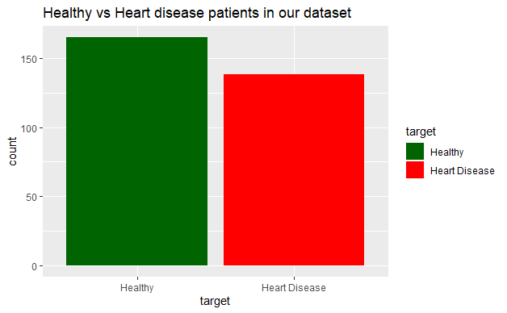

```r
ggplot(heart,aes(target, fill=target)) +
  geom_bar(stat="count") +
  scale_fill_manual(values=c("darkgreen","red")) +
  ggtitle("Healthy vs Heart disease patients in our dataset")
```

**Interpretation:**

As we can see from the plot above, we have more number of healthy patients in our dataset as compared to the heart disease patients.

2. To observe the effects of age with respect to healthy and heart disease patients, we’ve obtained the following Histograms.

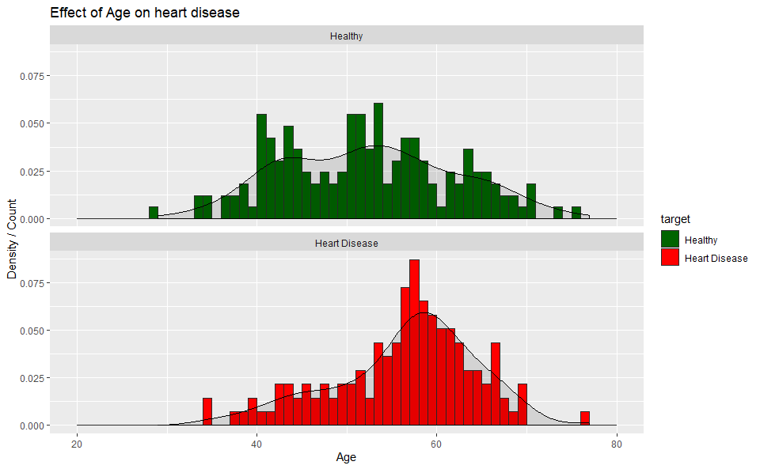

```r
ggplot(heart,aes(age, fill=target)) +
  geom_histogram(aes(y=..density..),breaks=seq(20,80, by=1), color="grey17") +
  geom_density(alpha=.1, fill="black")+
  facet_wrap(~target, ncol=1,scale="fixed") +
  scale_fill_manual(values=c("darkgreen","red"))+
  xlab("Age") +
  ylab("Density / Count") +
  ggtitle("Effect of Age on heart disease")
```

**Interpretation:**

From the plot above, we can see that the healthy patients are mostly uniformly distributed across the ages, whereas the heart disease patients seem to exhibit a negatively skewed histogram, peaking at close to the age of 60.

3. To understand if the maximum heart rate achieved during an exercise can be a possible indicator of an heart disease, we’ve plotted an histogram of maximum heart rate achieved during an exercise for both healthy and heart disease patients.

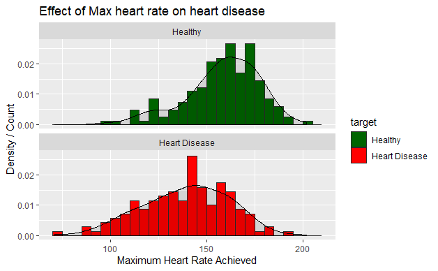

```r
ggplot(heart,aes(thalach, fill=target)) +
  geom_histogram(aes(y=..density..),breaks=seq(70, 210, by=5), color="grey17") +
  geom_density(alpha=.1, fill="black")+
  facet_wrap(~target, ncol=1,scale="fixed") +
  scale_fill_manual(values=c("darkgreen","red"))+
  xlab("Maximum Heart Rate Achieved") +
  ylab("Density / Count") +
  ggtitle("Effect of Max heart rate on heart disease")
```

**Interpretation:**

As we can see from the above plot that healthy patients have achieved a higher heart rate during the exercise as compared to the heart disease patients. This indicates that max heart rate achieved during an exercise can potentially be a useful indicator for a heart disease.

4. To observe the proportion of male and female having heart disease in our dataset, we’ve obtained a bar graph for male and female which is divided by red and green color to show the proportion of heart disease patients in each gender. We have also obtained a Histogram that shows the variability of age for male and female patients.

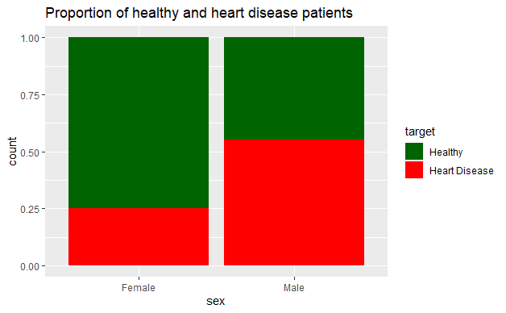

```r
bargraph_gender <- ggplot(heart, aes(x = sex, fill = target)) + geom_bar(position = "fill") +
scale_fill_manual(values=c("darkgreen","red")) +
ggtitle("Proportion of healthy and heart disease patients")
bargraph_gender
```

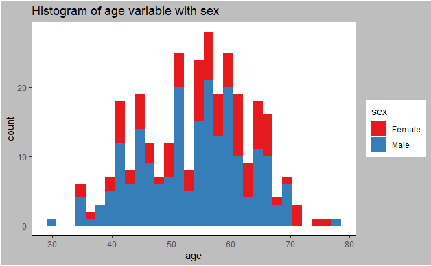

```r
hist_age <- ggplot(heart, aes(age, fill = sex))+geom_histogram(bins = 30)+theme_classic()+scale_color_brewer(palette="Set1")+scale_fill_brewer(palette = "Set1")+theme(plot.background = element_rect(fill = "gray"))+labs(title = "Histogram of age variable with sex", x = "age", y = "count")
hist_age
```

**Interpretation:**

As we can see from the bar graph above, proportion of male heart disease patients is almost more than double of the proportion of female heart disease patients in our dataset. This means that “sex” can be a strong variable in the prediction of a heart disease.

5. To observe if the heart disease patients exhibit a different type of chest pain compared to the healthy patients, we’ve plotted the following bar graphs for each of the chest pain types.

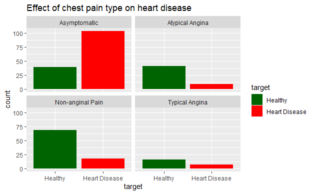

```r
ggplot(heart,aes(target, fill=target)) +
  geom_bar(stat="count") +
  facet_wrap(~cp, ncol=2,scale="fixed") +
  scale_fill_manual(values=c("darkgreen","red")) +
  ggtitle("Effect of chest pain type on heart disease")
```

```r
NA
NA
```

**Interpretation:**

From the plot above we can notice that Asymptomatic type of chest pain seems to be more common in heart disease patients, whereas atypical angina and non-anginal chest pain types seem to be more common with healthy patients. This shows that except Asymptomatic chest pain, other types show a negative correlation with respect to heart disease which can be useful in predicting heart disease.

6. To observe if the ECG holds a clue in determining heart disease in a patient, we’ve plotted the following graph with 3 different ECG results.

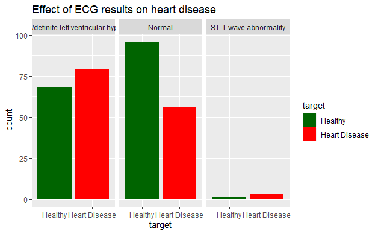

```r
ggplot(heart,aes(target, fill=target)) +
  geom_bar(stat="count") +
  facet_wrap(~restecg, ncol=3,scale="fixed") +
  scale_fill_manual(values=c("darkgreen","red")) +
  ggtitle("Effect of ECG results on heart disease")
```

**Interpretation:**

From the plot, we can notice that heart disease patients exhibit a definite left ventricular hypertrophy in their ECG results and healthy patients seem to have more number of normal ECG results.

7. To observe if exercise induced angina can be a strong predictor of heart disease, we’ve plotted the folllowing graph to observe its effects.

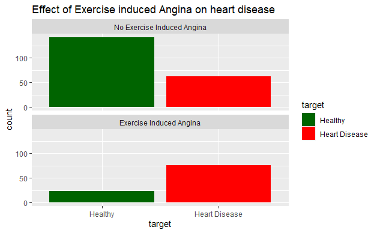

```r
ggplot(heart,aes(target, fill=target)) +
  geom_bar(stat="count") +
  facet_wrap(~exang, ncol=1,scale="fixed") +
  scale_fill_manual(values=c("darkgreen","red")) +
  ggtitle("Effect of Exercise induced Angina on heart disease")
```

**Interpretation:**

From the plot, we can notice that a large portion of healthy patients have no exercise induced angina wherease a large portion of heart disease patients have exercise induced angina. Therefore, this leads us to conclude that exercise induced angina can be a strong predictor of a heart disease.

8. To observe if resting blood pressure can indicate the presence of heart disease in a patient, we’ve obtained the following histograms to compare the blood pressures in healthy and heart disease patients.

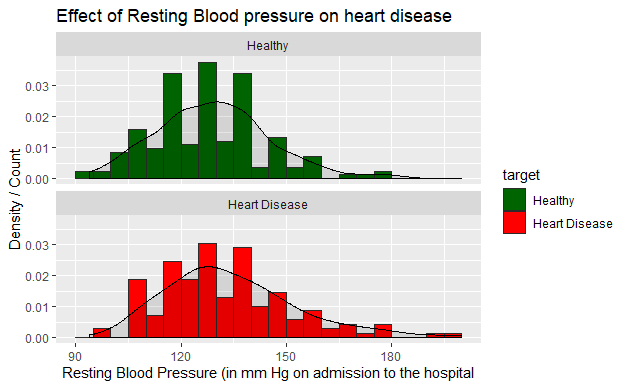

```r
ggplot(heart,aes(trestbps, fill=target)) +
  geom_histogram(aes(y=..density..),breaks=seq(90,200, by=5), color="grey17") +
  geom_density(alpha=.1, fill="black")+
  facet_wrap(~target, ncol=1,scale="fixed") +
  scale_fill_manual(values=c("darkgreen","red")) +
  xlab("Resting Blood Pressure (in mm Hg on admission to the hospital") +
  ylab("Density / Count") +
  ggtitle("Effect of Resting Blood pressure on heart disease")
```

**Interpretation:**

The skewness of the histogram for heart disease patients indicate that they exhibit slightly higher resting blood pressure than healthy patients. But we would need to conduct further test using regression to identify if it can be a reliable predictor of a heart disease.

9. To observe if the serum cholestrol level in patients can be a good indicator of a heart disease, we’ve obtained the following 2 histograms of serum cholestrol in healthy and heart disease patients.

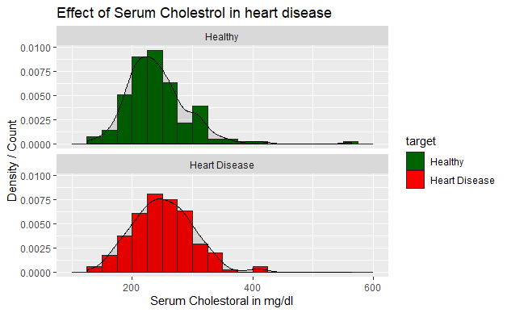

```r
ggplot(heart,aes(chol, fill=target)) +
  geom_histogram(aes(y=..density..),breaks=seq(100, 600, by=25), color="grey17") +
  geom_density(alpha=.1, fill="black")+
  facet_wrap(~target, ncol=1,scale="fixed") +
  scale_fill_manual(values=c("darkgreen","red")) +
  xlab("Serum Cholestoral in mg/dl") +
  ylab("Density / Count") +
  ggtitle("Effect of Serum Cholestrol in heart disease")
```

**Interpretation:**

From the histogram of heart disease patients, we can see that more number of patients are concentrated in the region of 250-300 mg/dl compared to the healthy patients. Barring that, the Histograms are somewhat similar and to identify if it can be a reliable indicator, we’d have to perform more tests.

10. To observe if the oldpeak parameter, i.e. the ST Depression induced by exercise can be a strong indicator of a heart disease, we’ve obtained the following histograms for healthy and heart disease patients.

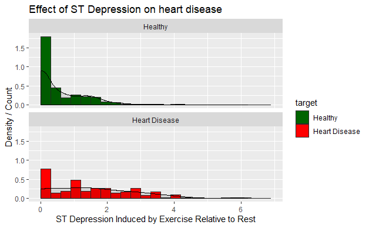

```r
ggplot(heart,aes(oldpeak, fill=target)) +
  geom_histogram(aes(y=..density..),breaks=seq(0, 7, by=0.3), color="grey17") +
  geom_density(alpha=.1, fill="black")+
  facet_wrap(~target, ncol=1,scale="fixed") +
  scale_fill_manual(values=c("darkgreen","red")) +
  ggtitle("Effect of ST Depression on heart disease") +
  xlab("ST Depression Induced by Exercise Relative to Rest") +
  ylab("Density / Count")
```

**Interpretation:**

From the histogram of heart disease patients, we can see that heart disease patients have more number of ST Depression induced by exercise than healthy patients. And it is significant enough to be a strong predictor of a heart disease.

11. To observe if the number of major vessels colored by Fluoroscopy, can help in indicating the presence of heart disease in a patient, we’ve obtained the following histograms to observe its effects.

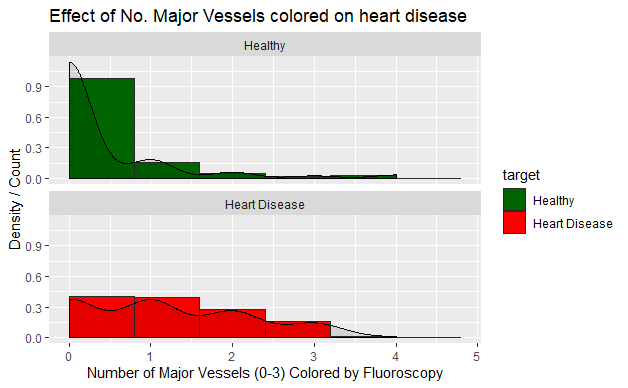

```r
ggplot(heart,aes(ca, fill=target)) +
  geom_histogram(aes(y=..density..),breaks=seq(0, 5, by=0.8), color="grey17") +
  geom_density(alpha=.1, fill="black")+
  facet_wrap(~target, ncol=1,scale="fixed") +
  scale_fill_manual(values=c("darkgreen","red")) +
  ggtitle("Effect of No. Major Vessels colored on heart disease") +
  xlab("Number of Major Vessels (0-3) Colored by Fluoroscopy") +
  ylab("Density / Count")
```

**Interpretation:**

From the histogram of heart disease patients, we can see that heart disease patients have more number of major blood vessels colored by Fluoroscopy than healthy patients. Therefore, this can be a major indicator for the presence of a heart disease.

12. To observe if the amount of fasting blood sugar, can help in indicating the presence of heart disease in a patient, we’ve obtained the following graph to observe its effects.

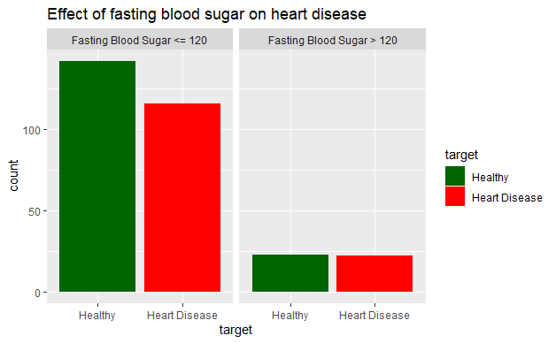

```r
ggplot(heart,aes(target, fill=target)) +
  geom_bar(stat="count") +
  facet_wrap(~fbs, ncol=2,scale="fixed") +
  scale_fill_manual(values=c("darkgreen","red")) +
  ggtitle("Effect of fasting blood sugar on heart disease")
```

**Interpretation:**

There doesn’t seem to be a significant effect of fasting blood sugar in the presence of heart disease. That being said, more number of healthy patients have a fbs of less than or equal to 120 than heart disease patients.

13. The Thallium Stress Test results have been plotted below to observe if heart disease patients exhibit a specific type of defect.

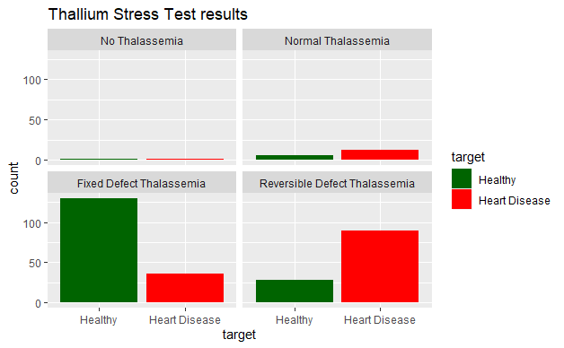

```r
ggplot(heart,aes(target, fill=target)) +
  geom_bar(stat="count") +
  facet_wrap(~thal, ncol=2,scale="fixed") +
  scale_fill_manual(values=c("darkgreen","red")) +
  ggtitle("Thallium Stress Test results")
```

**Interpretation:**

From the above Thallium Stress Test results, we can see that healthy patients seem to have fixed defect, whereas heart disease patients seem to have a reversible defect. For no and normal results, there isn’t any significant difference between the two.

### **Hypothesis Testing**

Here we will test the popular notion from our dataset that after a certain age, people are more likely to have a heart disease. To identify this certain age, we have taken the mean of all ages in our dataset which came to be 54.36.

We will begin with taking two subsets of our dataset. One will have all the patients with the heart disease, i.e. the target variable will be 1. The other will have all the patients with no heart disease, i.e. the target variable will be 0.

```r
heart_disease <-subset(heart, subset=(heart$target=="1"))
no_heart_disease <-subset(heart, subset=(heart$target=="0"))
```

Now we will proceed to test the Normality of the age variable in our heart dataset. For this, we will build a function using the in-built function of shapiro test so that we can just call this function anytime we have to perform a normality test.

```r
Normality_results<-function(data,alpha)
{
  shapiro_results = shapiro.test(data)
if (shapiro_results$p.value < alpha)
{
  cat("The distribution can be considered Normal, p-value=",shapiro_results$p.value)
}
 print(shapiro_results)
}
```

Similarly, we’ll build a global function to determine the result of a hypothesis test.

```r
test_classify <- function(test_object, alpha)
{
  if (test_object["p.value"] < alpha)
  {
    print(sprintf("NULL hypothesis should be rejected for `%s` test. p-value=%f is smaller than alpha=%#.4f",
            test_object["method"], test_object["p.value"],alpha))
    boolean_reject = TRUE
  } else
    {
    print(sprintf("NULL hypothesis cannot be rejected for `%s` test. p-value=%f is greater or equal than alpha=%#.4f",
            test_object["method"], test_object["p.value"],alpha))
    boolean_reject = FALSE
  }
  return (boolean_reject)
}
```

##### **Performing the Normality test using the function**

We will use the normality test function built earlier to determine the normality of the ages in our dataset. We have also ploted the histogram in order to understand the distribution of the data and solidify the normality test results.

```r
library(MASS)

Normality_results(heart$age ,0.05) #Normality Test
```

```
The distribution can be considered Normal, p-value= 0.005798359
    Shapiro-Wilk normality test

data:  data
W = 0.98637, p-value = 0.005798
```

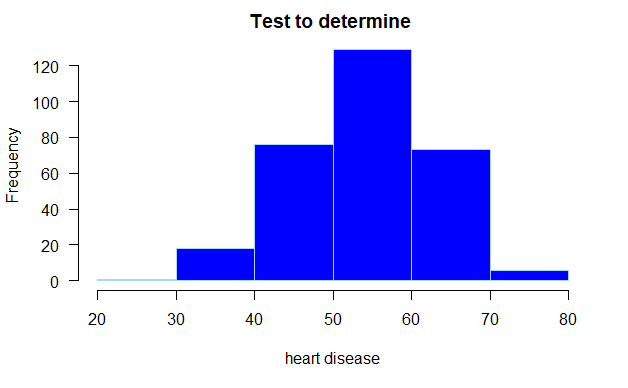

```r
hist(heart$age,main="Test to determine ",xlab="heart disease", border="light blue",col="blue",las=1,breaks = 5)
```

Below are the stated null and alternative hypotheses:

Null Hypothesis H0: The age of people with heart disease is mostly lesser than or equal to the average age 54.3. μ0: μa <= 54.3

Alternative Hypothesis H1: The age of people with heart disease is mostly greater than the average age 54.3

μ1: μa > 54.3

```r
#install.packages("TeachingDemos")
#Required for performing Z-Test
library(TeachingDemos)
#storing the standard deviation of the ages in sd_age as it is a required parameter in z-test
sd_age <- sd(heart$age)
#storing the mean of the ages in mean_age as it is a required parameter in z-test
mean_age <- mean(heart$age)
#performing z test on the subset of our dataset who have the heart disease, i.e. where target==1 is satisfied. The subset's name heart_disease has been used.
result=z.test(heart_disease$age , mu=mean_age, alternative = "greater", sd=sd_age, conf.level = 0.95)
result
```

```
    One Sample z-test

data:  heart_disease$age
z = 2.891, n = 138.00000, Std. Dev. = 9.08210, Std. Dev. of the
sample mean = 0.77312, p-value = 0.00192
alternative hypothesis: true mean is greater than 54.36634
95 percent confidence interval:
 55.32978      Inf
sample estimates:
mean of heart_disease$age
                 56.60145
```

```r
#using the function test_classify to interpret the results
test_classify(result, 0.05)
```

```
[1] "NULL hypothesis should be rejected for `One Sample z-test` test. p-value=0.001920 is smaller than alpha=0.0500"
[1] TRUE
```

As we can see from the one sample z-test that the p-value = 0.00192 which is lesser than the alpha 0.05. Therefore we can conclude that at a level of significance of 0.05, i.e. at a confidence level of 95%, there is sufficient evidence to reject our Null Hypothesis and accept our alternative hypothesis.

Therefore, there is statistically significant evidence from our dataset, to support the notion that higher age directly contributes to the likelihood of a heart disease.

### **Logistic Regression**

For heart disease prediction we are using logistic regression as it is one of the most powerful statistical way of modeling a binary outcome with one or more explanatory variables. It measures the relationship between the dependent and one or more independent variables by estimating probabilities using a logistic function, which is nothing but cumulative logistic distribution. This regression typically will help us to understand how the value of the dependent variables (target) changes when one of the independent variables (age,sex,cp etc) is adjusted and others are held fixed.

For our data set considered, we have used the glm() function, that is generalized linear models in order to fit the logistic regression model. The glm() function intakes the target (output) variable, the data set we are working on as well as family arguments as its inputs. Here, the argument family is set to binomial so that the function recognizes that we are performing a logistic regression and not any other kind of regression.

Using logistic regression to filter out important variables.

```r
logisticReg=glm(target~., data=heart, family=binomial)
summary(logisticReg)
```

```
Call:
glm(formula = target ~ ., family = binomial, data = heart)

Deviance Residuals:
    Min       1Q   Median       3Q      Max
-2.6007  -0.5302  -0.1525   0.3544   2.7777

Coefficients:
                                    Estimate Std. Error z value Pr(>|z|)
(Intercept)                       -1.1005784  3.3647651  -0.327  0.74360
age                                0.0005734  0.0235952   0.024  0.98061
sexMale                            1.5149396  0.5212317   2.906  0.00366
cpAtypical Angina                 -0.9832302  0.5640531  -1.743  0.08131
cpNon-anginal Pain                -1.9452318  0.4771939  -4.076 4.57e-05
cpTypical Angina                  -2.0159122  0.6506319  -3.098  0.00195
trestbps                           0.0170729  0.0107004   1.596  0.11059
chol                               0.0043317  0.0038894   1.114  0.26539
fbsFasting Blood Sugar > 120      -0.1764007  0.5661856  -0.312  0.75538
restecgNormal                     -0.5702065  0.3745081  -1.523  0.12787
restecgST-T wave abnormality       0.2767289  2.2672126   0.122  0.90285
thalach                           -0.0171314  0.0107357  -1.596  0.11055
exangExercise Induced Angina       0.7630837  0.4260285   1.791  0.07327
oldpeak                            0.4892926  0.2258040   2.167  0.03024
slopeFlat                          0.7196641  0.8630729   0.834  0.40437
slopeUpsloping                    -0.2015612  0.9382445  -0.215  0.82990
ca                                 0.8331781  0.2043120   4.078 4.54e-05
thalNormal Thalassemia            -1.8146869  2.3786093  -0.763  0.44551
thalFixed Defect Thalassemia      -1.8533188  2.2904818  -0.809  0.41844
thalReversible Defect Thalassemia -0.4732491  2.3013525  -0.206  0.83707

(Intercept)
age
sexMale                           **
cpAtypical Angina                 .
cpNon-anginal Pain                ***
cpTypical Angina                  **
trestbps
chol
fbsFasting Blood Sugar > 120
restecgNormal
restecgST-T wave abnormality
thalach
exangExercise Induced Angina      .
oldpeak                           *
slopeFlat
slopeUpsloping
ca                                ***
thalNormal Thalassemia
thalFixed Defect Thalassemia
thalReversible Defect Thalassemia
---
Signif. codes:  0 ‘***’ 0.001 ‘**’ 0.01 ‘*’ 0.05 ‘.’ 0.1 ‘ ’ 1

(Dispersion parameter for binomial family taken to be 1)

    Null deviance: 417.64  on 302  degrees of freedom
Residual deviance: 201.69  on 283  degrees of freedom
AIC: 241.69

Number of Fisher Scoring iterations: 6
```

The summary() function as we can see has returned the estimate, standard error, z-score and p-values on each of the coefficient.

For every data point which we have used in our model, the deviance associated with that point is calculated. Having done this each point we have a set of such residuals and ‘Deviance Residuals’ is providing us a non-parametric description of their distribution.

Under the coefficient section we can see for each of the predictor variables the ‘Estimate’ is providing us the co-efficient associated with them. Which is nothing but the estimated amount by which the log odds of target would increase if for example variable age were one unit higher, next column is providing the standard error associated with this estimate, i.e.it provides us an estimate of how much, on an average, these estimates would change if we were to rerun the entire study identically with new data over and over again. If we were to divide the estimate by standard error we will be getting a quotient which is assumed to be normally distributed whenever the sample is large enough. This value is given by z-value above. Further, the Pr(>|z|) are the two tailed p-values that corresponds to the z-values in a standard normal distribution.

Further, we can also see certain predictor variables have ’*’ in front of them stating their significance in the model.

The ‘Residual deviance’ is a measure of the lack of fit of our model as a whole and ‘Null deviance’ is such a measure for a reduced model that only includes intercept. Based on the number of predictor variables that were estimated in the model, those many number of degrees of freedom has been consumed in their calculation. which is shown in the deviance section.

Also, the AIC(Akaike information criterion) is another measure of goodness of fit that takes into account the ability of the model to fit the data, this will enable us to judge which model is better later in the document when we perform similar modeling again. model with lower AIC is doing a better job describing the variance in the data.

Lastly, the fisher scoring iteration refers to how the model was estimated, this model has been solved by the ‘Newton-Raphson algorithm’. Mostly, the model is fit based on a guess about what the estimates might be. The algorithm then looks around to see if the fit would be improved by using different estimates instead. If so, it moves in that direction. Finally the algorithm stops when it doesn’t perceive that moving again would yield any additional improvement. From the output we can see that we have had 6 iterations before the process stopped and we got the output results.

From the output above we can see that of all the predictors, the model has recognized sex,cp,exang,oldpeak,ca and target as important predictors. All the important vectors are now stored in a vector for further analysis.

Considering only important variables

```r
data_imp=heart[,c(2,3,9,10,12,14)]
summary(data_imp)
```

```
     sex                     cp                             exang
 Female: 96   Asymptomatic    :143   No Exercise Induced Angina:204
 Male  :207   Atypical Angina : 50   Exercise Induced Angina   : 99
              Non-anginal Pain: 87
              Typical Angina  : 23


    oldpeak           ca                   target
 Min.   :0.00   Min.   :0.0000   Healthy      :165
 1st Qu.:0.00   1st Qu.:0.0000   Heart Disease:138
 Median :0.80   Median :0.0000
 Mean   :1.04   Mean   :0.7294
 3rd Qu.:1.60   3rd Qu.:1.0000
 Max.   :6.20   Max.   :4.0000
```

The summary function of the important predictors has returned us the count of each kind of variable withing the predictors. From the output we can see details such as there are 96 females and 207 males, the exang predictor has two variables and 204 patients have no exercise induced angina whereas 99 of the patients recorded exercise induced angina.

```r
logisticReg=glm(target~.,data=data_imp,family=binomial)
summary(logisticReg)
```

```
Call:
glm(formula = target ~ ., family = binomial, data = data_imp)

Deviance Residuals:
    Min       1Q   Median       3Q      Max
-2.5038  -0.5714  -0.2011   0.5202   2.3277

Coefficients:
                             Estimate Std. Error z value Pr(>|z|)
(Intercept)                   -1.9614     0.4348  -4.511 6.44e-06 ***
sexMale                        1.4117     0.3894   3.625 0.000289 ***
cpAtypical Angina             -1.3498     0.4868  -2.773 0.005560 **
cpNon-anginal Pain            -2.0905     0.4192  -4.987 6.12e-07 ***
cpTypical Angina              -2.0161     0.6086  -3.313 0.000924 ***
exangExercise Induced Angina   1.2217     0.3721   3.283 0.001028 **
oldpeak                        0.8060     0.1810   4.454 8.42e-06 ***
ca                             0.7635     0.1662   4.595 4.34e-06 ***
---
Signif. codes:  0 ‘***’ 0.001 ‘**’ 0.01 ‘*’ 0.05 ‘.’ 0.1 ‘ ’ 1

(Dispersion parameter for binomial family taken to be 1)

    Null deviance: 417.64  on 302  degrees of freedom
Residual deviance: 238.32  on 295  degrees of freedom
AIC: 254.32

Number of Fisher Scoring iterations: 5
```

```r
logisticReg.df=tidy(logisticReg)
```

After considering only important predictor variables from the above output, we can confirm that all the predictor variables are now significant and the number of iteration that has taken to fit the model is less compared to our earlier model.

plotting the results obtained from logistic regression, we are using the mutate() function in order to create a new variable ‘term’ which will re-organize our data frame so as to include the ‘estimates’ of our model. The revised data frame is then used to plot using the ggplot() function as below.

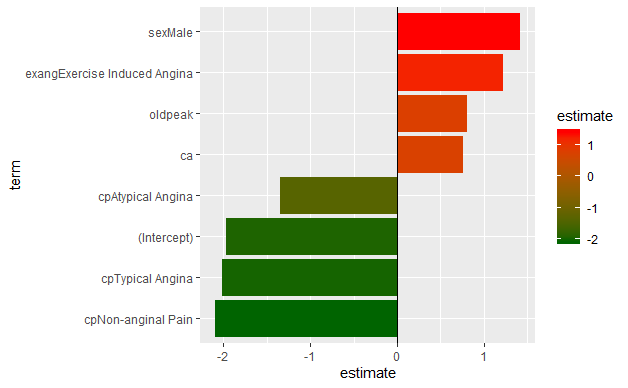

```r
logisticReg.df %>%
  mutate(term=reorder(term,estimate)) %>%
  ggplot( aes(term,estimate, fill=estimate)) +
  geom_bar(stat="identity") +
  scale_fill_gradient(low="darkgreen", high="red") +
  geom_hline(yintercept=0) +
  coord_flip()
```

From the plot we can see, that if the patient has a chest pain which is either a Non anginal Pain, Typical Anginal pain or atypical anginal pain, the probability of them having Heart Disease decreases drastically.

We can also observe that, greater the number of blood vessels that are colored by fluroscopy(ca), greater are the chances of that patient having a heart disease.

Also, higher the exercise induced ST Depression (oldpeak) observed in a patient, higher are the chances of him/her having a Heart Disease.

If a patient has exercise induced angina, then the probability of him/her having a Heart Disease increases significantly.

Lastly, if the patient is a male, then there is a high chance of him having a Heart Disease as compared to being a female.

For further analysis, a plot of the effect of ST depression in male and female patients in inducing heart disease has been plotted as below using ggplot() function, further stat_smooth() function has been used so as to enable smooth lines whenever there is over plotting.

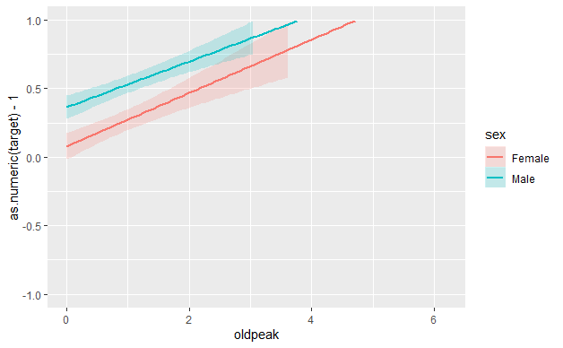

```r
ggplot(heart, aes(oldpeak, as.numeric(target)-1,color=sex )) +
  stat_smooth(method="glm",  formula=y~x,
              alpha=0.2, size=1, aes(fill=sex)) +
  ylim(-1,1)
```

From the plot we can see that the as ST depression rises, chances of a patient having heart disease rises too. We observe a direct correlation.

Another plot in order to visualize the effect of number of blood vessels colored by fluroscopy in the blood samples of males and female patients on heart disease has been created. Similar to the previous plot, we have used ggplot() function in order to plot the data with stat_smooth function so as to smooth the lines to avoid over plotting.

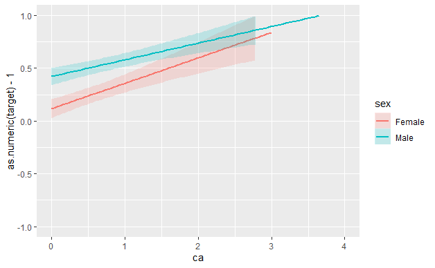

```r
ggplot(heart, aes(ca, as.numeric(target)-1, color=sex)) +
  stat_smooth(method="glm",  formula=y~x,
              alpha=0.2, size=1, aes(fill=sex)) +
  ylim(-1,1)
```

From the plot, we can observe that as the number of blood vessels colored by fluoroscopy in the blood sample of an individual increases, the probability of heart disease in that individual increases. This probability increase more sharply in females as compared to males.

Now we will sample a training dataset from the important dataset that has the useful parameters obtained earlier.

```r
data=data_imp
set.seed(1237)
train=sample(nrow(data), .8*nrow(data), replace = FALSE)
TrainSet=data[train,]
TestSet=data[-train,]

#Tuning parameters
fitControl=trainControl(method = "repeatedcv",
                           number = 10,
                           repeats = 10,
                           classProbs = TRUE,
                           summaryFunction = twoClassSummary)


TrainSet$target=make.names(TrainSet$target)
set.seed(142)
TrainSet$target=as.factor(TrainSet$target)
```

trainControl function has been used in order to control the computational nuances of the train function.

We have used ‘repeatedcv’ method in order to get repeated training/test splits, with 10 folds cross validation.

Now that we have a train set, we will use logistic regression with train function from caret package.

```r
logisticReg_train=caret::train(target ~ .,
                                      data = TrainSet ,
                                      method = "glm",
                                      trControl = fitControl,
                                      metric="ROC")

logisticReg_train
```

```
Generalized Linear Model

242 samples
  5 predictor
  2 classes: 'Healthy', 'Heart.Disease'

No pre-processing
Resampling: Cross-Validated (10 fold, repeated 10 times)
Summary of sample sizes: 219, 218, 218, 217, 217, 218, ...
Resampling results:

  ROC        Sens       Spec
  0.8978199  0.8749451  0.79
```

The sensitivity(true positive rate) refers to the number of instances from the positive class that was actually predicted correctly and a sensitivity value of 0.874 states that our model did a pretty good job in predicting the true positives.

To check the importance of each variables, we’ll use the varImp function as below.

```r
varImp(logisticReg_train, scale = FALSE)
```

```
glm variable importance
```

|  | Overall |
| --- | --- |
| `cpNon-anginal Pain` | 4.790982 |
| oldpeak | 3.937727 |
| `cpTypical Angina` | 3.714235 |
| ca | 3.672094 |
| sexMale | 3.662294 |
| `cpAtypical Angina` | 2.878090 |
| `exangExercise Induced Angina` | 2.396322 |

As we can see, chest pain type non-anginal pain has received the maximum importance, followed by oldpeak, typical angina, ca, male, atypical cp and exercise induced angina.

Now, let’s predict on the test set and check the accuracy of the result using confusion matrix.

```r
logisticReg_pred <- predict(logisticReg_train,TestSet)
levels(logisticReg_pred)[2] <- "Heart Disease"

table_pred<-table(logisticReg_pred, TestSet$target)
table_pred.df<-as.data.frame(table_pred)

result_pred<-caret::confusionMatrix(table_pred, positive="Heart Disease")
result_pred
```

```
Confusion Matrix and Statistics


logisticReg_pred Healthy Heart Disease
   Healthy            24             9
   Heart Disease       7            21

               Accuracy : 0.7377
                 95% CI : (0.6093, 0.842)
    No Information Rate : 0.5082
    P-Value [Acc > NIR] : 0.0002142

                  Kappa : 0.4747

 Mcnemar's Test P-Value : 0.8025873

            Sensitivity : 0.7000
            Specificity : 0.7742
         Pos Pred Value : 0.7500
         Neg Pred Value : 0.7273
             Prevalence : 0.4918
         Detection Rate : 0.3443
   Detection Prevalence : 0.4590
      Balanced Accuracy : 0.7371

       'Positive' Class : Heart Disease
```

We can see the accuracy of our model was quite good, which is almost 74% accurate prediction.

### **Decision tree**

Another approach which we considered in order to determine whether a certain individual has heart disease based on various predictor variables is decision tree. A decision tree algorithm primarily works on the grounds of recursive partitioning. In this technique we will be repeatedly partitioning the predictor variables into multiple sub-levels based on their significance, such that the outcome in each sub-level is as homogeneous as possible. The output obtained with such a method thus will contain a set of rules made up of different predictor/input variables which can be used in predicting the outcome/target variable in our case healthy/heart disease.

To begin with, we have used the expand.grid() function which creates a data frame which is the Cartesian product of its arguments. Here it is primarily used to plot predicted responses over various combinations of values for predictor variables in our data set. Further, trainControl function is used in order to control the computational nuances of the train function. We have used ‘repeatedcv’ method in order to get repeated training/test splits, with 10 folds cross validation. We have also enabled the calculation of class probabilities for the decision tree classification model and lastly we have used twoclasssummary function in order to compute the performance metric across the resamples.

```r
Tree_Grid=expand.grid(cp=c(0.01))
fitControl=trainControl(method = "repeatedcv",
                           number = 10,
                           repeats = 10,
                           classProbs = TRUE,
                           summaryFunction = twoClassSummary)

data_imp$target=make.names(data_imp$target)

decisiontree_train = caret::train(target ~ .,
                                      data = data_imp ,
                                      method = "rpart",
                                      trControl = fitControl,
                                      metric="ROC",
                                      tuneGrid=Tree_Grid)
decisiontree_train
```

```
CART

303 samples
  5 predictor
  2 classes: 'Healthy', 'Heart.Disease'

No pre-processing
Resampling: Cross-Validated (10 fold, repeated 10 times)
Summary of sample sizes: 273, 272, 273, 272, 274, 273, ...
Resampling results:

  ROC        Sens       Spec
  0.8196294  0.8326838  0.7430769

Tuning parameter 'cp' was held constant at a value of 0.01
```

From the output we can see that the train function has provided us the 5 significant predictor variables as well as the two target classes that we have considered healthy and heart disease. We have also received a summary of our sample sizes considered in the training set.

In order to determine the importance of variables in the object’decisiontree_train’ produced by our train function we are using Rs built-in ’varImp() function which has taken in the training set predictors as its data argument.

```r
varImp(decisiontree_train)
```

```
rpart variable importance
```

|  | Overall |
| --- | --- |
| oldpeak | 100.00000 |
| exangExercise Induced Angina | 94.55902 |
| cpNon-anginal Pain | 69.68827 |
| ca | 61.06672 |
| sexMale | 55.04316 |
| cpAtypical Angina | 11.54127 |
| `cpAtypical Angina` | 0.00000 |
| `cpTypical Angina` | 0.00000 |
| `cpNon-anginal Pain` | 0.00000 |
| `exangExercise Induced Angina` | 0.00000 |

We can see that the function has returned the importance of various predictor variables in the data set.

Finally with the help of the rpart.plot() function we are plotting the decision tree as below.

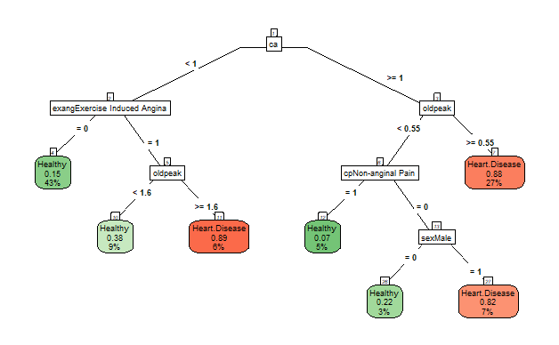

```r
rpart.plot(decisiontree_train$finalModel,
           type=5,
           fallen.leaves = FALSE,
           box.palette = "GnRd",
           nn=TRUE)
```

From the output we can make the following observations:

Deeper the color red on leaf nodes, higher the probability for a patient with characteristic leading to that lead node having a Heart Disease.

The decimal value denotes the probability of that particular outcome. The percentage under it denoted the proportion of that outcome in the dataset.

ca is the most prominent predictor variable i.e. the Number of major blood vessels (0-3) colored by fluroscopy.

oldpeak: ST depression induced by exercise relative to rest is second most prominent predictor.

We can make predictions such as, if number of blood vessels colored by fluoroscopy >= 1 and ST depression < 0.55 and he/she has doesn’t have a non-anginal chest pain, and the patient is a male, then there is an 82% chance for that patient having a Heart Disease.

Similarly, doctors can take a decision based on these parameters whether there is a chance of Heart Disease in the future.

### **Conclusion**

We can conclude that only a few of the parameters from our initial 14, have a significant impact on Heart Disease.

Gender, Chest Pain Type, Exercise Induced Angina, ST Depression & No. of vessels observed by fluoroscopy are the only variables that have a significant effect on Heart Disease.

These parameters can be used to construct a simple interactive application for predicting heart disease, avoiding the Invasive procedure of coronary angiography, a current diagnosis method which is costly and associated with mortality in coronary artery disease patients.

All these conclusions can be vital for the doctors of today and the doctors to be of the future (Advanced AI) in accurately diagnosing a patient with a heart disease which can help in faster treatment and a subsequent recovery.

### **References**

1. Hamid Reza Marateb and Sobhan Goudarzi, A noninvasive method for coronary artery diseases diagnosis using a clinically-interpretable fuzzy rule-based system Circulation. J Res Med Sci. 2015 Mar; 20(3): 214–223. retrieved from https://www.ncbi.nlm.nih.gov/pmc/articles/PMC4468223/
2. Project McNulty: Estimating the Risk of Heart Disease. May 15, 2015 retrieved from https://lucdemortier.github.io/projects/3_mcnulty
3. Heart Disease UCI. ronit(Version 1) retrieved from https://www.kaggle.com/ronitf/heart-disease-uci
4. Heart Disease Data Set retrieved from https://archive.ics.uci.edu/ml/datasets/Heart+Disease

### **Appendix**

In this project we have used the heart disease data set sourced from the University of california Irvine’s Machine Learning Repository. This data set dates from 1988 and originally consisted of four databases: Cleveland (303 instances), Hungary (294), Switzerland (123), and Long Beach VA (200).

As the other databases had missing values, only the cleveland database has been used for this project. Out of the 76 initial attributes, 14 have been used as the rest had gotten corrupted.

One of the major setbacks we have had during this project was that our target variables had incorrect labels in the data-set. Every analysis and outcome interpreted and obtained were totally opposite to the known facts. 80% into the project completion, we had to reiterate interpretations in order to present the accurate facts.